# Analysis of mammary glands

Using DESeq2

Kasper D. Hansen

Fall 2022

# Data

Analysis is based on the paper “RNA-seq analysis is easy as 1-2-3 with limma, Glimma and edgeR” by Law et al (2018, F1000Res).

Data is RNA-seq data from the mammary glands of female mice in triplicate.

Cells have been sorted into 3 cell populations: basal, luminal progenitors (LP) and mature luminal (ML)

> In this instance, reads were aligned to the mouse reference genome (mm10) using the R based pipeline available in the Rsubread package (specifically the align function followed by featureCounts for gene-level summarisation based on the in-built mm10 RefSeq-based annotation).

# Notes

We only focus on 2 out of the 3 cell populations, to make things simple.

We don’t control for batch effects and we don’t model the fact that the cell populations are paired, in the sense that one sample has been sorted into three different populations.

# Loading the data

```r
library(DESeq2)
load("mamgland_rse.rda")
```

# Inspecting the data

```r
mamgland_rse
```

```
## class: RangedSummarizedExperiment
## dim: 27179 9
## metadata(1): version
## assays(1): counts
## rownames(27179): 497097 100503874 ... 100861691 100504472
## rowData names(4): rownames ENTREZID SYMBOL TXCHROM
## colnames(9): 10_6_5_11 9_6_5_11 ... JMS9-P7c JMS9-P8c
## colData names(3): files group lane
```

```r
colData(mamgland_rse)
```

```
## DataFrame with 9 rows and 3 columns
##                          files    group     lane
##                    <character> <factor> <factor>
## 10_6_5_11 GSM1545535_10_6_5_11    LP        L004
## 9_6_5_11   GSM1545536_9_6_5_11    ML        L004
## purep53     GSM1545538_purep53    Basal     L004
## JMS8-2       GSM1545539_JMS8-2    Basal     L006
## JMS8-3       GSM1545540_JMS8-3    ML        L006
## JMS8-4       GSM1545541_JMS8-4    LP        L006
## JMS8-5       GSM1545542_JMS8-5    Basal     L006
## JMS9-P7c   GSM1545544_JMS9-P7c    ML        L008
## JMS9-P8c   GSM1545545_JMS9-P8c    LP        L008
```

```r
rowData(mamgland_rse)
```

```
## DataFrame with 27179 rows and 4 columns
##            rownames    ENTREZID       SYMBOL     TXCHROM
##           <integer> <character>  <character> <character>
## 497097            1      497097         Xkr4        chr1
## 100503874         2   100503874      Gm19938          NA
## 100038431         3   100038431      Gm10568          NA
## 19888             4       19888          Rp1        chr1
## 20671             5       20671        Sox17        chr1
## ...             ...         ...          ...         ...
## 100861837     27204   100861837           NA          NA
## 100861924     27205   100861924           NA          NA
## 170942        27206      170942       Erdr1x        chrY
## 100861691     27207   100861691 LOC100861691          NA
## 100504472     27208   100504472           NA          NA
```

There are many (27k) genes

# Making a DDS object

```r
rse <- mamgland_rse[, mamgland_rse$group %in% c("Basal", "LP")]
dds <- DESeqDataSet(rse, design = ~ group)
```

```
## factor levels were dropped which had no samples
```

```r
dds$group
```

```
## [1] LP    Basal Basal LP    Basal LP
## Levels: Basal LP
```

We see that the reference level is `Basal`

# PCA

For PCA to work well, it is usually a good idea to use a proper transformation on the data. Of particular concern for RNA-seq data are

- The effect of library size (sequencing depth).
- The mean-variance relationship.

One possibility is to apply a **variance stabilizing transformation**. We will avoid the details, but in DESeq2 there are two options `rlog()` (slower) and `vst()` (faster). We will use the former here.

`rlog()` produces data which is on the $\log_2$-scale and has been corrected for library size, so it is straightforward to use in a PCA.

```r
rld <- rlog(dds, blind = TRUE)
```

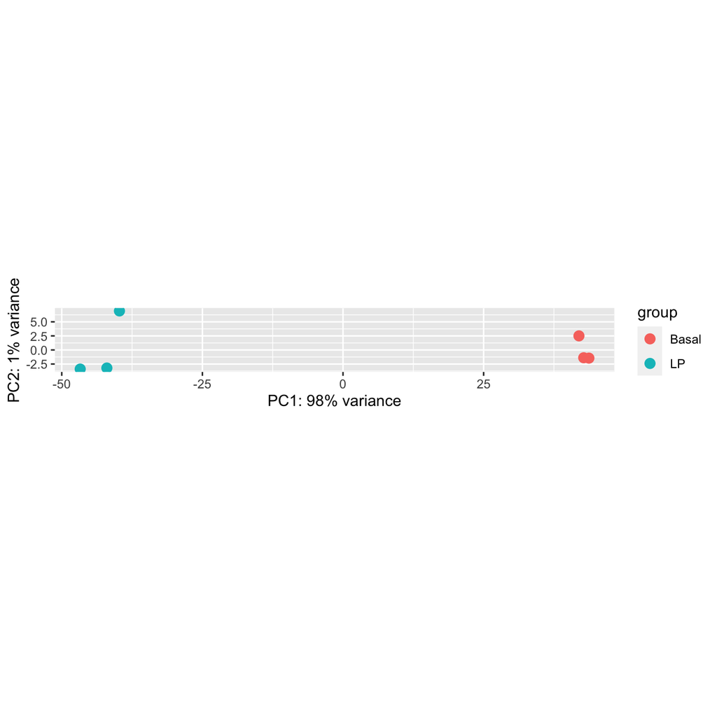

```r
plotPCA(rld, intgroup = "group")
```

In this plot, the axes are scaled by the amount of variation explained. This is a recommended visualization method, but often harder to do and most PCA plot you see, don’t do this.

Here, we see that `group` explains a whopping 98% of the variation. So either there is something wrong, or we are going to get a huge amount of differential expression.

# Running DESeq2

- expression filtering
- dispersion (variance) shrinkage
- testing

```r
dds <- DESeq(dds)
resultsNames(dds)
```

```
## [1] "Intercept"         "group_LP_vs_Basal"
```

```r
res <- results(dds)
```

# Expression filtering

In DESe2, expression filtering happens by default using independent filtering.

In addition, adjusted p-values are not computed for genes which are thought to have “outliers”.

```r
sum(is.na(res$padj))
```

```
## [1] 7607
```

```r
sum(is.na(res$log2FoldChange))
```

```
## [1] 5539
```

```r
summary(subset(res, is.na(padj))$baseMean)
```

```
##    Min. 1st Qu.  Median    Mean 3rd Qu.    Max.
## 0.00000 0.00000 0.00000 0.08239 0.11525 0.71155
```

```r
summary(subset(res, is.na(log2FoldChange))$baseMean)
```

```
##    Min. 1st Qu.  Median    Mean 3rd Qu.    Max.
##       0       0       0       0       0       0
```

```r
summary(subset(res, is.na(padj) & !is.na(log2FoldChange))$baseMean)
```

```
##    Min. 1st Qu.  Median    Mean 3rd Qu.    Max.
##  0.1152  0.1277  0.2514  0.3031  0.4734  0.7115
```

# Dispersion shrinkage

We can check the dispersion shrinkage by plotting it. This is good practice. It is possible to find datasets where the assumptions are violated, if it looks dramatically different from the one below.

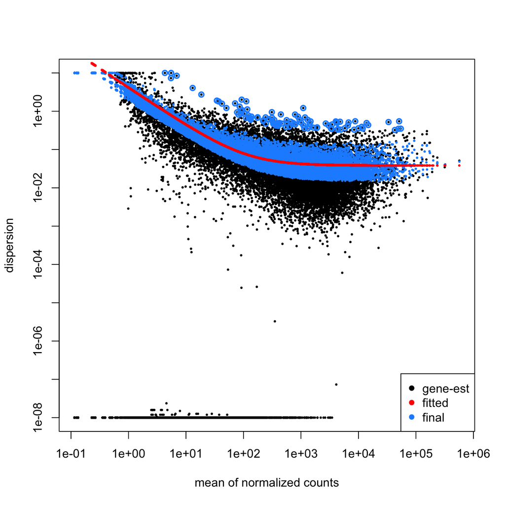

```r
plotDispEsts(dds)
```

# Results

Let’s look at the results

```r
res
```

```
## log2 fold change (MLE): group LP vs Basal
## Wald test p-value: group LP vs Basal
## DataFrame with 27179 rows and 6 columns
##             baseMean log2FoldChange     lfcSE       stat      pvalue
##            <numeric>      <numeric> <numeric>  <numeric>   <numeric>
## 497097    178.132189      -7.814822  0.798833 -9.7828038 1.33461e-22
## 100503874   2.010761      -4.045448  1.888161 -2.1425329 3.21506e-02
## 100038431   0.127682      -0.142802  4.080473 -0.0349964 9.72083e-01
## 19888       0.251387       2.241987  4.055295  0.5528542 5.80363e-01
## 20671      31.442171      -2.504787  0.634167 -3.9497249 7.82411e-05
## ...              ...            ...       ...        ...         ...
## 100861837   335.9564      -0.121568  0.336319  -0.361466   0.7177509
## 100861924    26.9728      -1.465920  0.846686  -1.731362   0.0833872
## 170942      889.2336       0.157340  0.256641   0.613073   0.5398284
## 100861691     0.0000             NA        NA         NA          NA
## 100504472     0.0000             NA        NA         NA          NA
##                  padj
##             <numeric>
## 497097    1.82664e-21
## 100503874 6.55676e-02
## 100038431          NA
## 19888              NA
## 20671     2.79237e-04
## ...               ...
## 100861837    0.802091
## 100861924    0.148504
## 170942       0.653910
## 100861691          NA
## 100504472          NA
```

Per default, the ordering of results in R is the same order as the genes. So we have a mix of significant, not significant and not expressed (and therefore not tested) genes

The columns are

- `baseMean`: average expression (on count scale) of the gene **across all samples**.
- `log2FoldChange`: the log2FC of the gene across the two groups we compared. This column is harder to interpret if you’re comparing three or more groups with one test.
- `lfcSE`: estimated standard error of the `log2FoldChange` column.
- ``stat`: Just `log2FoldChange` / `lfcSE`
- `pvalues`: unadjusted p-values
- `padj`: adjusted p-values. Default method is Benjamini Horchberg, so this targets a False Discovery Rate.

Let’s look at a gene

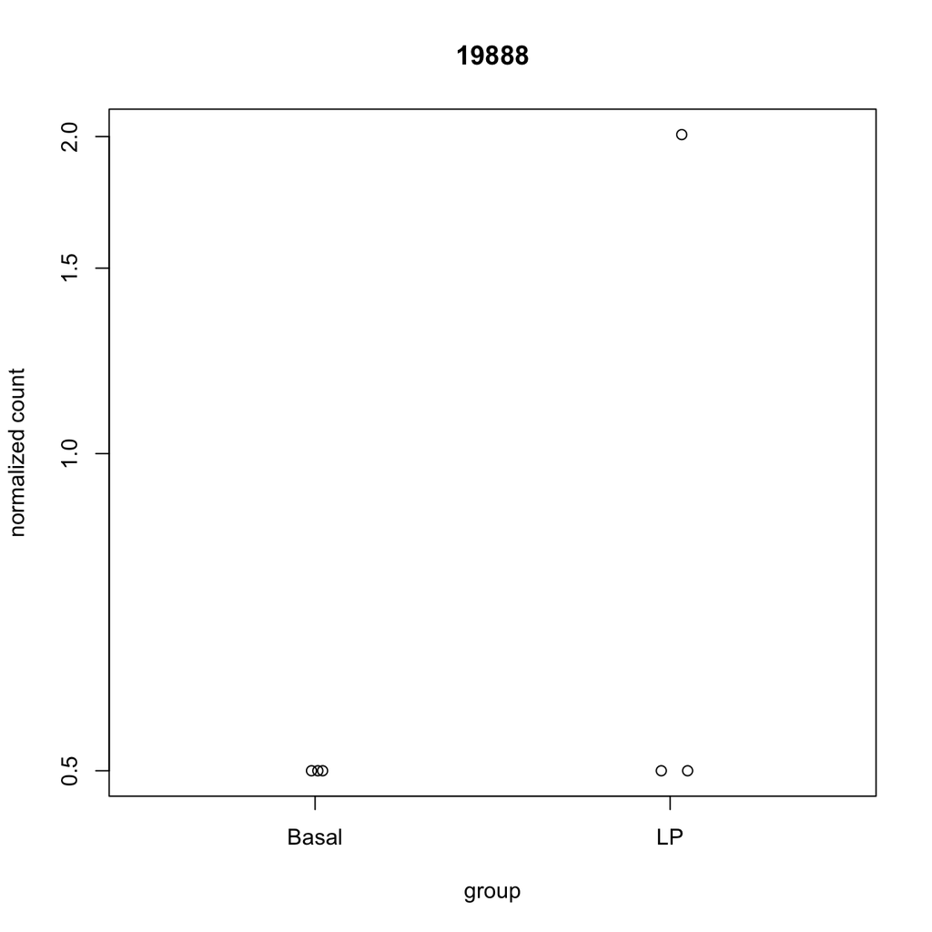

```r
plotCounts(dds, "19888", intgroup = "group")
```

We can see how many significant genes we have

```r
sum(res$padj <= 0.1, na.rm = TRUE)
```

```
## [1] 10278
```

That’s a HUGE amount of differential expression.

We can look at the results ranked by p-value

```r
resOrd <- res[order(res$padj), ]
resOrd
```

```
## log2 fold change (MLE): group LP vs Basal
## Wald test p-value: group LP vs Basal
## DataFrame with 27179 rows and 6 columns
##            baseMean log2FoldChange     lfcSE      stat       pvalue
##           <numeric>      <numeric> <numeric> <numeric>    <numeric>
## 12994     132886.39        7.14098  0.204120   34.9843 3.90414e-268
## 11600       3256.04        6.65260  0.193237   34.4272 9.88582e-260
## 16664      92683.25       -7.81553  0.243703  -32.0700 1.15710e-225
## 14233       1932.16        6.86139  0.215624   31.8211 3.30606e-222
## 13711       8048.82        6.22488  0.196010   31.7579 2.46853e-221
## ...             ...            ...       ...       ...          ...
## 100040357         0             NA        NA        NA           NA
## 100861808         0             NA        NA        NA           NA
## 100504460         0             NA        NA        NA           NA
## 100861691         0             NA        NA        NA           NA
## 100504472         0             NA        NA        NA           NA
##                   padj
##              <numeric>
## 12994     7.64118e-264
## 11600     9.67427e-256
## 16664     7.54892e-222
## 14233     1.61766e-218
## 13711     9.66282e-218
## ...                ...
## 100040357           NA
## 100861808           NA
## 100504460           NA
## 100861691           NA
## 100504472           NA
```

# P-value distribution

It is always a good idea to look at the p-value distribution

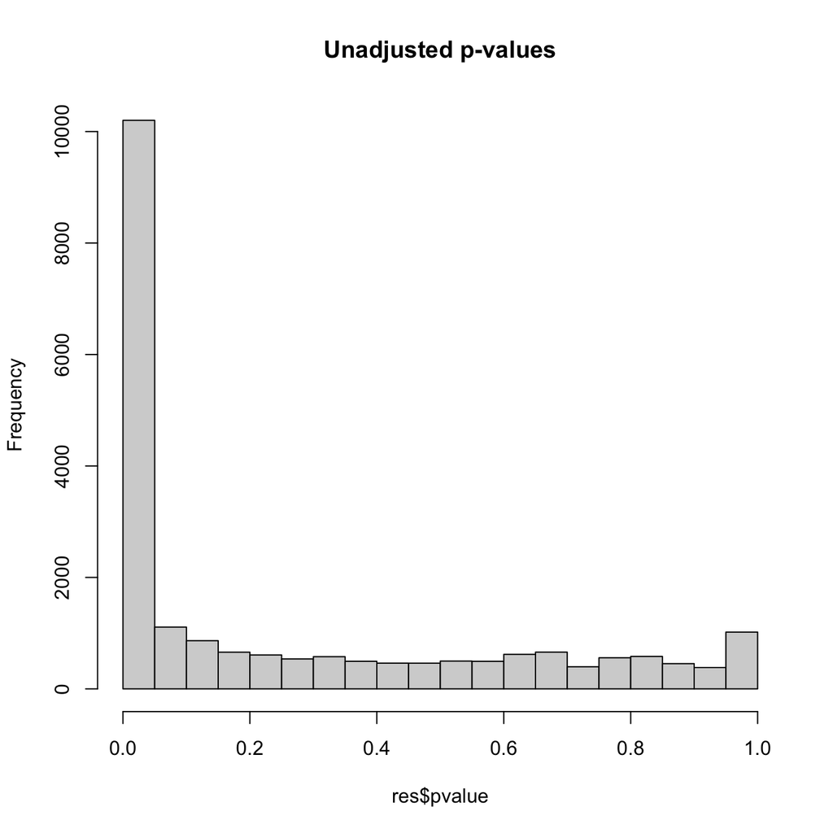

```r
hist(res$pvalue, main = "Unadjusted p-values")
```

Looks good, but reinforces that we have a huge amount of significant genes.

# Mean-difference plot

A mean-difference plot is always a good idea to look at. These are also (for historical reasons) called MA plots in genomics.

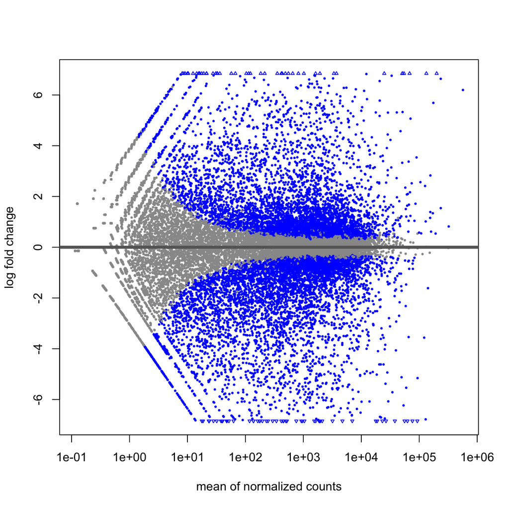

```r
plotMA(res)
```

# Fold-change shrinkage

DESeq2 also allows for shrinkage of the fold changes. This is in general considered a good idea. Fold-change shrinkage does not affect testing, but it is useful for plotting and ranking genes

```r
resLFC <- lfcShrink(dds, coef = "group_LP_vs_Basal")
```

```
## using 'apeglm' for LFC shrinkage. If used in published research, please cite:
##     Zhu, A., Ibrahim, J.G., Love, M.I. (2018) Heavy-tailed prior distributions for
##     sequence count data: removing the noise and preserving large differences.
##     Bioinformatics. https://doi.org/10.1093/bioinformatics/bty895
```

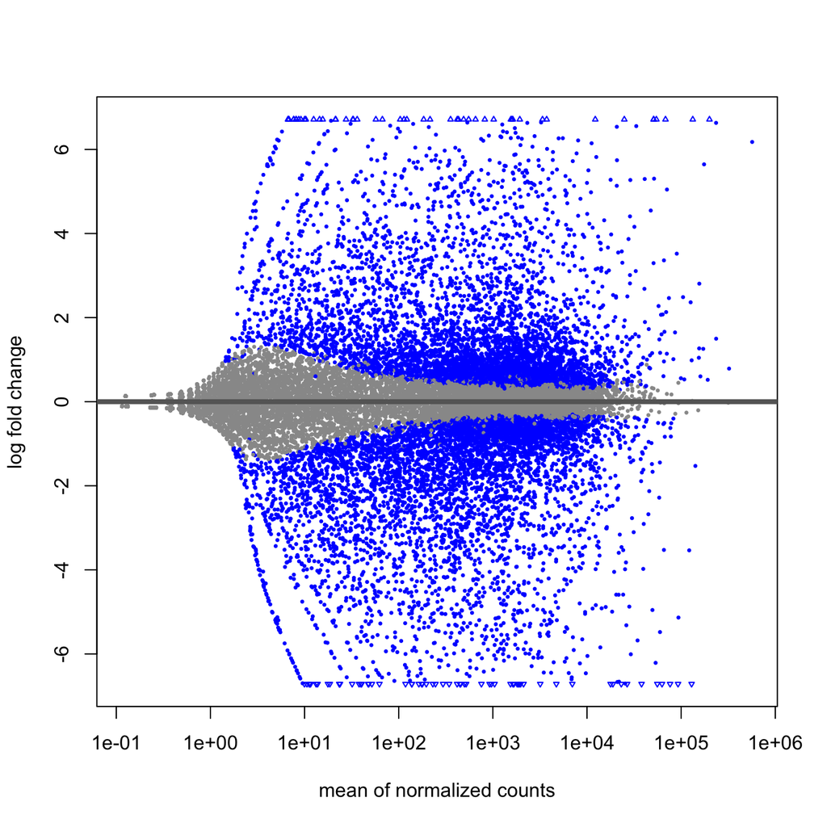

```r
plotMA(resLFC)
```